# Injuries in the NFL

Christopher Spartz

11/15/2021

### Background Information

I will take some time to explain what the NFL and American Football are, since not everyone nows what American football is. Firstly, the NFL is the professional league of American Football in the U.S. and it is easily the most popular sport in the U.S. The goal of a game of American Football is to score more points than the other team, and in order to score points you must bring the football to your endzone at one end of the field. While one team on the offense attempts to score in the endzone, the other team attempts to stop the offense using their defense who can tackle opposing players to make a play stop where the player with the football was tackled. Those tackles can easily lead to injuries, which is what the focus of my analysis today is about.

### Questions

Before I started working with this data I had a few questions that I was hoping to answer:  
1. Have the number of injuries to player gone up in recent years?  
2. What position tends to get injured more than others?  
3. How do injuries to players affect the winning percentage of teams?  
4. What teams are best at not getting injured?  
5. What team can win despite injuries?

### Data Wrangling

```r
library(rvest)
library(stringr)
library(tidyverse)
library(ggplot2)
library(purrr)
#library(lubridate)
library(xml2)

teamids <- c('mia','nwe','buf','nyj','pit','rav','cin','cle','jax','oti',
           'htx','clt','kan','sdg','rai','den','phi','dal','was','nyg',
           'min','det','gnb','chi','nor','car','atl','tam','ram','sea',
           'crd','sfo')
years <- c(2010,2011,2012,2013,2014,2015,2016,2017,2018,2019,2020)
```

Starting off this exploration into team reported injuries in the NFL from 2010 to 2020 we have the initial setup here where I create the functions to scrape the Pro Football Reference and input that data into 2 data frames that I then join in order to get access to all of that data that I need to analyze the injuries reported over this time span.

```r
team_inj <- function(t) {
  c <- 1
  tinj <- list()
  for (y in seq_along(years)) {
    url <- sprintf("https://www.pro-football-reference.com/teams/%s/%d_injuries.htm",t,years[y])
    i <- url %>%
      read_html()%>%
      html_node('table#team_injuries')%>%
      html_table()
    i <- i[c(1:17)]
    names(i) <- c("Player","Game_1","Game_2","Game_3","Game_4","Game_5","Game_6","Game_7","Game_8","Game_9",
              "Game_10","Game_11","Game_12","Game_13","Game_14","Game_15","Game_16")
    i <- i %>% pivot_longer(!c("Player"),names_to = "Game",values_to = "Injury")
    i <- i %>% separate(Game,c(NA,"Game"),"_")
    i <- i[!(is.na(i$Injury) | i$Injury==""), ]
    i <- i %>% mutate(year=years[y],
                  team=t)
    i$Player <- as.factor(i$Player)
    tinj[[c]] <- i
    c <-  c+1
  }
  big_inj <- tinj %>% bind_rows()
}
```

```r
teaminj <- list()
c <- 1
for (t in seq_along(teamids)) {
  teaminj[[c]] <- team_inj(teamids[[t]])
  c <- c+1
}
all_inj <- teaminj %>% bind_rows()
```

```r
all_inj <- all_inj %>% filter(Injury!="//")
all_inj <- all_inj %>% filter(Injury!="//;90")
all_inj <- all_inj %>% filter(Injury!="S")
all_inj$Injury <- as.factor(all_inj$Injury)
all_inj$Injury <- factor(all_inj$Injury,levels = c("C19","P","Q","D","O","IR","PUP"))
```

In the team_inj function I grab all of the webpages of injuries for a team over a time span which look like [This](https://www.pro-football-reference.com/teams/sdg/2020_injuries.htm) and place the reported injuries of one team into one big data frame. In order to the clean the data that I got from the website I had to rename a large number of the columns and then pivot longer to get the data into a more usable format. After I am done creating the team_inj function I invoke inside of a loop and create a data frame of injuries for each team, which then get bound together into one extremely large data frame. Finally, I take out some of the injury classifications that are not importan to my analysis and set the injuries to appropiate factor levels.

```r
team_starters <- function(t) {
  url <- sprintf("https://www.pro-football-reference.com/teams/%s/lineups.htm#starting_lineups",t)
  lin <- read_html(url)
  p <- lin %>%
    html_node('table#starting_lineups')

  xml_find_all(p, ".//br") %>% xml_add_sibling("p", "\n")

  xml_find_all(p, ".//br") %>% xml_remove()
  p <- p %>% html_table()
  p <- p %>% pivot_longer(!c("Year","Record"),names_to = "Position Group",values_to = "Players") %>% filter(Year>2009)
  p1 <- p %>% separate(Players,c("Player_1","Player_2","Player_3","Player_4","Player_5","Player_6"),sep = "\n")
  p2 <- p1 %>% pivot_longer(!c("Year","Record","Position Group"),names_to = "Field") %>% na.omit()
  p3 <- p2 %>% mutate(value = str_replace(value, "\\s", "|")) %>%
    separate(value, into = c("Position", "Player"), sep = "\\|")
  p3$"Player" <- str_remove_all(p3$'Player','[*+]')
  p3 <- p3 %>% select(-Field)
  p3 <- p3 %>% mutate(team=t)
}
```

```r
teamStart <- list()
c <- 1
for (t in seq_along(teamids)) {
  teamStart[[c]] <- team_starters(teamids[[t]])
  c <- c+1
}
all_starters <- teamStart %>% bind_rows()
all_starters$Player <- as.factor(all_starters$Player)
all_starters$Position <- factor(all_starters$Position,levels = c("QB","RB","FB","WR","TE","LT","LG","C",
                                                                 "RG","RT","LDT","RDT","DE","DT","NT","LDE","RDE",
                                                                 "LOLB","LILB","RILB","ROLB","LLB","MLB","RLB",
                                                                 "LCB","RCB","CB","DB","SS","FS","PR","KR"))
all_starters <- all_starters %>% separate(Record,c("Wins","Losses","Ties"), sep = "-")
all_starters$Wins <- as.numeric(all_starters$Wins)
all_starters$Losses <- as.numeric(all_starters$Losses)
all_starters$Ties <- as.numeric(all_starters$Ties)
```

In order to find the starters of every team in the NFL over this time span I went to sites like [This](https://www.pro-football-reference.com/teams/chi/lineups.htm) which have a list of every starter for a team in its history. The wrangling of this data was a little more difficult as the player names had to moved around a bit in order to get every Starting player’s name so that then I could join the two data frames together. Otherwise the process for finding the starters for each team was fairly similar to getting the injury information.

```r
all_starters$Player <- str_trim(all_starters$Player)
alltogether <- all_starters %>% rename(year=Year) %>% inner_join(all_inj, by=c("Player","year","team"))
alltogether$team <- as.factor(alltogether$team)
```

### Injury reports over the Years

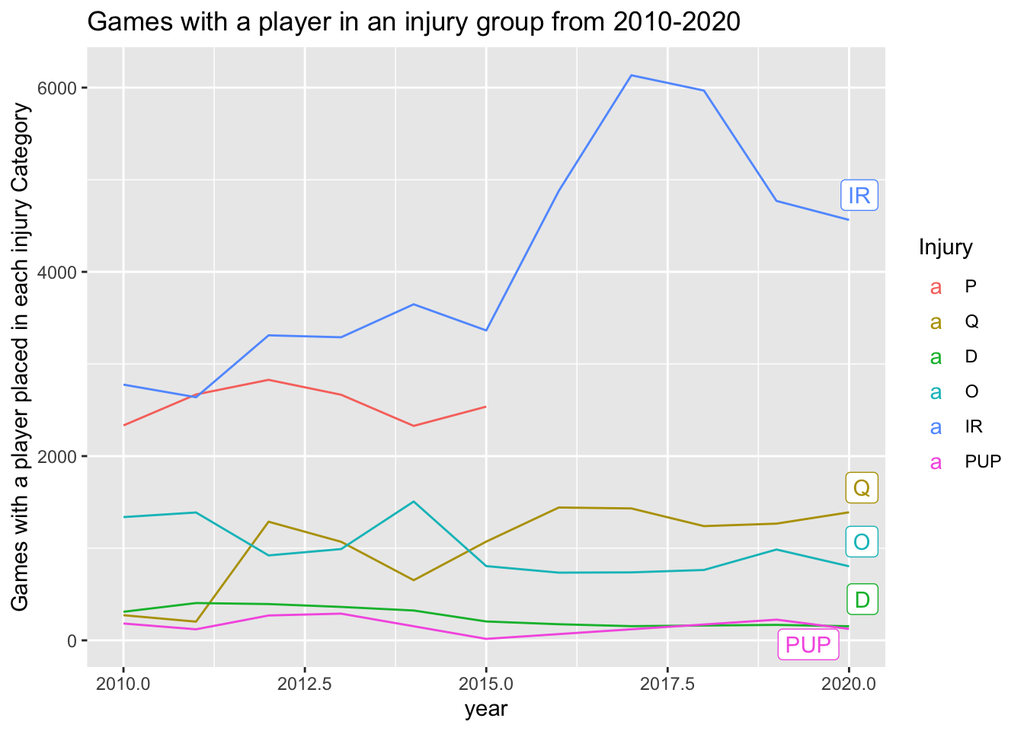

```r
library(ggrepel)
all_inj %>% group_by(Injury,year) %>% count(Injury) %>% unique() %>% filter(Injury!="C19") %>%
  mutate(label = if_else(year == 2020, as.character(Injury), NA_character_)) %>%
  ggplot(aes(x=year,y=n, group=Injury , color=Injury)) +
  geom_line() +
  geom_label_repel(aes(label = label),
                  nudge_x = 1,
                  na.rm = TRUE) +
  ylab("Games with a player placed in each injury Category") +
  ggtitle("Games with a player in an injury group from 2010-2020")
```

While the previous graph looked at all injuries over the period spanning 2010-2020, the remaining graphs will only look at the injuries that starting players sustained. The criteria for who is a starter is that they were reported as a starter at the begining of a season which means that they’ll appear on a Pro Football Reference page like [This](https://www.pro-football-reference.com/teams/chi/lineups.htm). The reason that I made this decision is that injuries to backups tend to have a lesser impact on the game as a whole since most starters play almost every play of a typical football game. Additionally, when a starter is injured that often means that a team will have to adjust its game plan and that can seriously change how a team approaches a game and can affect the overall outcome of the game.

### Number of times reported as injured by position

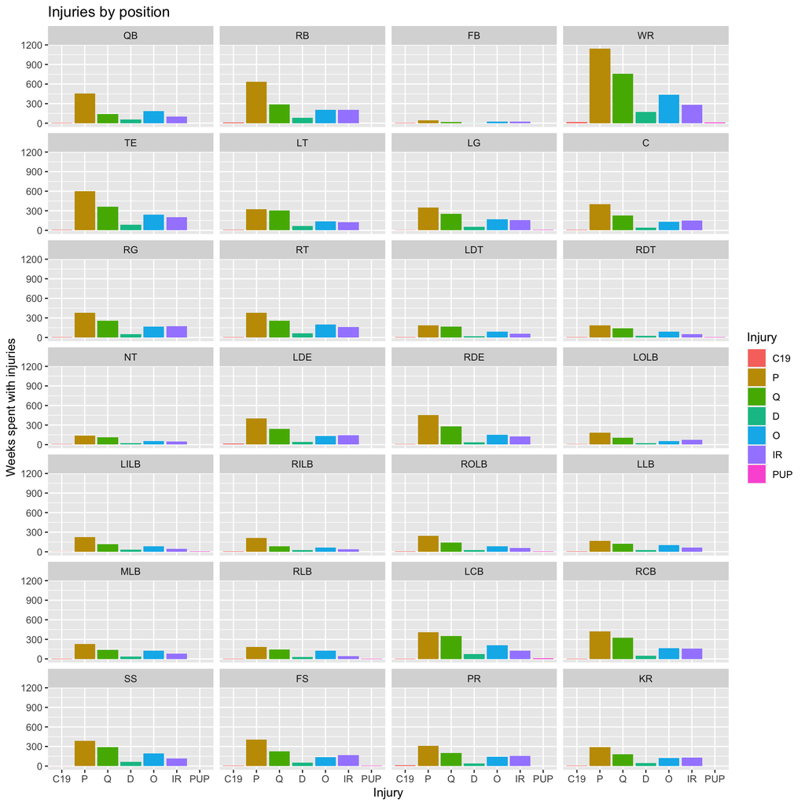

```r
impPos <- alltogether[!(alltogether$Position=="DE" | alltogether$Position=="DT" |
                          alltogether$Position=="CB" | alltogether$Position=="DB"),]
impPos %>% group_by(Injury,Position) %>% count(Injury) %>%
  ggplot(aes(x=Injury,y=n, fill=Injury)) +
  geom_bar(stat = "Identity") +
  ggtitle("Injuries by position") +
  ylab("Weeks spent with injuries") +
  facet_wrap(~Position,ncol = 4)
```

### League wide injuries vs. winning percentage throughout each year

For the next 2 graphs I removed all of the times that a player was reported as probable since NFL teams stopped reporting players as probable in 2015, which led to inconsistent data being presented in this graph.

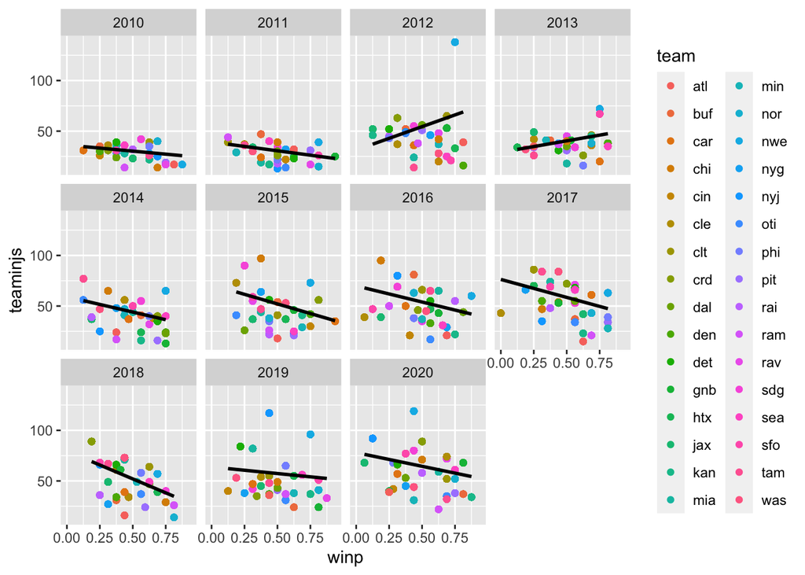

```r
nopr <- alltogether %>% filter(Injury!="P")
nopr %>% group_by(team,year) %>%
  mutate(teaminjs=n(), winp=(Wins+0.5*Ties)/16) %>%
  ggplot(aes(x=winp,y=teaminjs, color=team)) +
  geom_point() +
  geom_smooth(method=lm , color="black", se=FALSE) +
  facet_wrap(~year)
```

This graph shows that on average the best teams in the league tend to have less injuries. Just because less injured teams tend to have a better winning percentage does not mean that that is always the case like in 2012 and 2013 where a couple of teams who had lost a fair number of starters were able to win a lot of games. Overall a team has a better chance of winning if they have less injuries, which is a concept that makes total sense since it is difficult to adjust to losing a player in a game due to injury.

### Winning percentage of teams compared to the number of Injuries

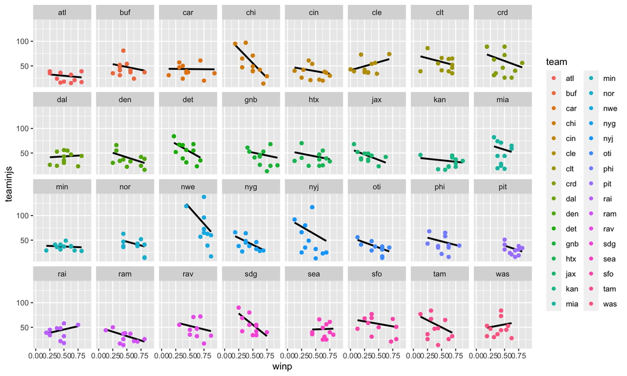

```r
nopr %>% group_by(team,year) %>%
  mutate(teaminjs=n(), winp=(Wins+0.5*Ties)/16) %>%
  ggplot(aes(x=winp,y=teaminjs,color=team))  +
  geom_smooth(method=lm , color="black", se=FALSE) +
  geom_point() + facet_wrap(~team,ncol = 8)
```

After looking at the last graph the question that comes up is how well does each team deal with injuries to their starters in a season. This chart attempts determine that, and also see what teams tend to deal with the most injuries. Some teams like the Chicago Bears(chi) and the Los Angeles Chargers (sdg) do not tend to deal with injuries very well and also tend to deal with a fair number of injuries. On the other side of the coin there are teams like the Atlanta Falcons (atl) and the Pittsburgh Steelers (pit) tend to not get injured much and win more often than other teams that get more injuries. Finally there are the New England Patriots(nwe) who tend to deal with injuries extremely well, even when they deal with a large number of injuries they still tend to have one of the highest winning percentages over this time span. However, even a team that deals with injuries extremely well like the Patriots can still struggle to win as many games as normal when they have a lot of injuries to starters.  
Overall this graph shows that most teams tend to win more when less starters are injured.